# Zadanie rekrutacyjne - Otodom

## Wstęp

Serwis Otodom w ostatnich latach inwestował duże nakłady finansowe na marketing, co pozwoliło na znacznie zwiększenie liczby potencjalnych kupujących. Inwestycje przynoszą korzyści ogłoszeniodawcom, którzy dzięki większemu zainteresowaniu otrzymują zdecydowanie więcej zapytań. Z uwagi na to, serwis zaczął zastanawiać się, czy mógłby zwiększyć ceny za dodawanie ogłoszeń, żeby zapewnić sobie możliwość dalszych inwestycji.

Zarząd zdecydował o przeprowadzeniu testów cenowych dla użytkowników dodających ogłoszenia celem ustalenia optymalnej ceny. W praktyce poszczególnym klientom pokazywano różne ceny za te same usługi. W każdej kategorii klient może skorzystać z 3 pakietów i na ten moment zdecydowano się na testowanie tylko jednego z nich dla każdej z kategorii.

Celem dla serwisu jest maksymalizacja przychodów przy jednocześnie jak najmniejszej stracie liczby ogłoszeń. Ogłoszenia są dla serwisu niezwykle istotne i nie może sobie pozwolić na zbyt duże straty. Przygotuj kompleksową analizę danych, której wynikiem będą rekomenacje co do wprowadzenia lub nie nowych cen w danych kategoriach.

### Zebranie danych

```r
knitr::opts_chunk$set(echo = TRUE)
library(dplyr)
library(pander)
library(DBI)
library(tidyr)
library(lubridate)
library(ggplot2)
library(magrittr)

#system("psql -U postgres -h 127.0.0.1 -f ./data/ab_data.sql")
#system("psql -U postgres -h 127.0.0.1 -f ./data/pp_users.sql")
db_user <- params$db_user
db_password <- params$db_password
db <- 'postgres'
host_db <- '127.0.0.1'
db_port <- '5432'
con <- dbConnect(RPostgres::Postgres(),
                 dbname = db,
                 host=host_db,
                 port=db_port,
                 user=db_user,
                 password=db_password)
ab_data.query <- 'SELECT * FROM public.ab_data'
ab_data <- dbGetQuery(con, ab_data.query)
pp_users.query <- 'SELECT * FROM public.pp_users'
pp_users <- dbGetQuery(con, pp_users.query)
pp_users <- pp_users %>%
  mutate_all(as.character)

all_data <- ab_data %>% left_join(pp_users, by = 'user_id')
all_data$group_pp <- ifelse(all_data$group_pp.x=='', all_data$group_pp.y, all_data$group_pp.x) %>%
  as.factor()
all_data$created_at  <- all_data$created_at %>% as.Date()
all_data$price <- as.numeric(all_data$price)
all_data <- all_data %>%
  select(-c(group_pp.x,group_pp.y))
```

92 użytkowników nie posiada żadnego przypisania do grupy, w związku z czym zostaną oni usunięci z analizy.

```r
roundUp <- function(x){
  round(x/100, 0)*100
}
calc_price <- function(x, mean=TRUE){
  prices <- names(x) %>% as.numeric()
  pricesVector <- vector(mode="numeric", length=length(prices))

  for(i in 1:length(prices)){
      pricesVector[i] <- prices[i]*x[i]
  }
  if(mean==TRUE){
    sum(pricesVector)/sum(x)
  } else {
    sum(pricesVector)/sum(x[2:length(x)])
  }


}

calc_decrease_client <- function(x){
  round(x[1]/sum(x),2)
}
```

### Eksploracja i czyszczenie danych

Czyszczenie danych

1. usunięcie osób bez przypisanej grupy

```r
all_data <- all_data %>%
  filter(!is.na(group_pp))
```

2. Ponieważ w treści zadania zauwazyć można iż “zdecydowano się na testowanie tylko jednego z nich dla każdej z kategorii” tylko jedna kategoria musi zostać wybrana do analizy oraz kategoria bazowa. Z informacji otrzymanych w korespondencji mailowej wynika, że testowany był pakiet “75”.

```r
table(all_data$category_id,
      all_data$id_index) %>%
  addmargins() %>%
  pander()
```

|  | 0 | 121 | 123 | 75 | Sum |
| --- | --- | --- | --- | --- | --- |
| **102** | 1197 | 1680 | 195 | 1531 | 4603 |
| **201** | 312 | 761 | 204 | 462 | 1739 |
| **401** | 447 | 646 | 114 | 565 | 1772 |
| **502** | 130 | 287 | 82 | 212 | 711 |
| **Sum** | 2086 | 3374 | 595 | 2770 | 8825 |

Pakiet “0” jest w rzeczywistości sytuacją, w której użytkownik nie zdecydował się na kupno pakietu, a więc nie poniósł żadnych kosztów (price == 0), a status pozostał nieopłacony (status == ‘unpaid’). Testowany pakiet “75” posiada 2770 ogłoszeń.

```r
wybrany_pakiet <- 75
data_all_packages <- all_data
all_data <- all_data %>%
  filter(id_index %in% c(0, wybrany_pakiet))
```

Liczba ogłoszeń wczucanych przez użytkowników:

```r
all_data %>%
  filter(id_index == wybrany_pakiet) %>%
  select(user_id) %>%
  table() %>%
  table() %>%
  pander()
```

| 1 | 2 | 3 | 4 | 5 | 7 | 8 |
| --- | --- | --- | --- | --- | --- | --- |
| 2477 | 99 | 13 | 6 | 2 | 2 | 1 |

Na ogół użytkownicy wrzucali po 1-2 ogłoszenia.

czy zdarza się, że więcej niż jedno ogłoszenie ma ten sam identyfikator?

```r
all_data$id <- 1:nrow(all_data)
duplicated_rows <- all_data %>%
  select(-created_at, -id) %>%
  duplicated()
duplicated_data <- all_data %>%
  filter(ad_id %in% all_data$ad_id[duplicated(all_data$ad_id)]) %>%
  arrange(ad_id)
duplicated_without_date <- duplicated_data %>% select(-created_at) %>% unique()

duplicated_data
```

| created_at | status | ad_id | user_id | category_id | id_index | price | group_pp | id |
| --- | --- | --- | --- | --- | --- | --- | --- | --- |
| 2020-02-13 | unpaid | 120442244 | 4984068 | 401 | 0 | 0 | 2 | 2069 |
| 2020-02-26 | unpaid | 120442244 | 4984068 | 401 | 0 | 0 | 2 | 2070 |
| 2020-02-14 | unpaid | 120445020 | 14577712 | 201 | 0 | 0 | 2 | 2089 |
| 2020-02-17 | unpaid | 120445020 | 14577712 | 201 | 0 | 0 | 2 | 2090 |
| 2020-02-14 | unpaid | 120445526 | 1395022 | 102 | 0 | 0 | 3 | 40 |
| 2020-02-16 | unpaid | 120445526 | 1395022 | 102 | 0 | 0 | 3 | 41 |
| 2020-02-14 | unpaid | 120445946 | 9931600 | 502 | 0 | 0 | 3 | 2359 |
| 2020-02-17 | unpaid | 120445946 | 9931600 | 502 | 0 | 0 | 3 | 2360 |
| 2020-02-23 | unpaid | 120445946 | 9931600 | 502 | 0 | 0 | 3 | 2361 |
| 2020-02-27 | unpaid | 120445946 | 9931600 | 502 | 0 | 0 | 3 | 2362 |

[output cut: 130 more lines]

140 ogłszeń posiada zduplikowany identyfikator. Są zgłaszane przez tego samego użytkownika, nieopłacone i są duplikatami powstałymi w różnych dniach, ale przynależącymi do tej samej kategorii i wewnątrz tych samych grup testowych. Ponieważ przypisane są do tych samych użytkowników można usunąć duplikaty z analizy pozostawiając unikatowe (poza datą utworzenia) rekordy. Jednocześnie zaleca się zweryfikować, dlaczego mogą powtarzać się identyfikatory ogłoszeń - taka sytuacja nie powinna mieć miejsca.

```r
all_data <- all_data %>%
  filter(!id %in% all_data[duplicated_rows, 'id'])
```

Struktura danych testowania cen:

```r
all_data <- all_data %>%
  mutate(status = factor(status),
         category_id = factor(category_id),
         id_index = factor(id_index))
all_data %>%
  glimpse()
```

```
## Observations: 4,784
## Variables: 9
## $ created_at  <date> 2020-02-21, 2020-02-20, 2020-03-06, 2020-03-02, 2020-0...
## $ status      <fct> paid, paid, paid, unpaid, paid, unpaid, unpaid, unpaid,...
## $ ad_id       <chr> "120501038", "120495432", "120605050", "120564670", "12...
## $ user_id     <chr> "2032070", "14600180", "1272426", "14634088", "14485146...
## $ category_id <fct> 102, 102, 201, 401, 102, 102, 102, 102, 401, 401, 401, ...
## $ id_index    <fct> 75, 75, 75, 0, 75, 0, 0, 0, 0, 0, 75, 75, 75, 75, 75, 7...
## $ price       <dbl> 49, 39, 59, 0, 49, 0, 0, 0, 0, 0, 49, 49, 39, 49, 59, 5...
## $ group_pp    <fct> 2, 1, 2, 1, 2, 2, 2, 1, 2, 2, 1, 2, 1, 1, 3, 3, 3, 3, 2...
## $ id          <int> 1, 2, 3, 4, 5, 6, 7, 8, 10, 11, 12, 13, 14, 15, 16, 17,...
```

```r
all_data %>%
  summary() %>%
  pander()
```

Table continues below

| created_at | status | ad_id | user_id |
| --- | --- | --- | --- |
| Min. :2020-02-13 | paid :2770 | Length:4784 | Length:4784 |
| 1st Qu.:2020-02-19 | unpaid:2014 | Class :character | Class :character |
| Median :2020-02-25 | NA | Mode :character | Mode :character |
| Mean :2020-02-25 | NA | NA | NA |
| 3rd Qu.:2020-03-03 | NA | NA | NA |
| Max. :2020-03-08 | NA | NA | NA |

| category_id | id_index | price | group_pp | id |
| --- | --- | --- | --- | --- |
| 102:2689 | 0 :2014 | Min. : 0.00 | 1:1750 | Min. : 1 |
| 201: 761 | 75:2770 | 1st Qu.: 0.00 | 2:1718 | 1st Qu.:1220 |
| 401: 999 | NA | Median :39.00 | 3:1316 | Median :2434 |
| 502: 335 | NA | Mean :29.64 | NA | Mean :2431 |
| NA | NA | 3rd Qu.:49.00 | NA | 3rd Qu.:3641 |
| NA | NA | Max. :69.00 | NA | Max. :4856 |

```r
all_data$price %>%
  table() %>%
  pander()
```

| 0 | 39 | 42 | 49 | 59 | 69 |
| --- | --- | --- | --- | --- | --- |
| 2014 | 624 | 88 | 1034 | 754 | 270 |

Podział użytkowników na grupy testowe wg kategorii:

```r
userGroups <- table(all_data$category_id,
                    all_data$group_pp)
userGroups %>%
  addmargins() %>%
  pander()
```

|  | 1 | 2 | 3 | Sum |
| --- | --- | --- | --- | --- |
| **102** | 982 | 984 | 723 | 2689 |
| **201** | 267 | 287 | 207 | 761 |
| **401** | 373 | 334 | 292 | 999 |
| **502** | 128 | 113 | 94 | 335 |
| **Sum** | 1750 | 1718 | 1316 | 4784 |

W każdej z 4 kategorii podział pomiędzy grupami testowymi nie jest znacznie zaburzony. Zaobserwować można, że w 3-ciej grupie testowej jest zawsze najmniej ogłoszeń. Może to wynikać również ze średniej ceny, która jak widać poniżej wzrasta wraz z kolejnym numerem grupy:

```r
mean_price <- all_data %>%
  filter(id_index == wybrany_pakiet) %>%
  group_by(category_id,group_pp) %>%
    summarise(n = n(),
              mean_price = mean(price))
mean_price
```

| category_id | group_pp | n | mean_price |
| --- | --- | --- | --- |
| 102 | 1 | 624 | 39.00000 |
| 102 | 2 | 558 | 49.00000 |
| 102 | 3 | 349 | 59.00000 |
| 201 | 1 | 172 | 49.00000 |
| 201 | 2 | 169 | 59.00000 |
| 201 | 3 | 121 | 69.00000 |
| 401 | 1 | 234 | 48.97009 |
| 401 | 2 | 182 | 59.00000 |
| 401 | 3 | 149 | 69.00000 |
| 502 | 1 | 87 | 42.00000 |

[output cut: 2 more lines]

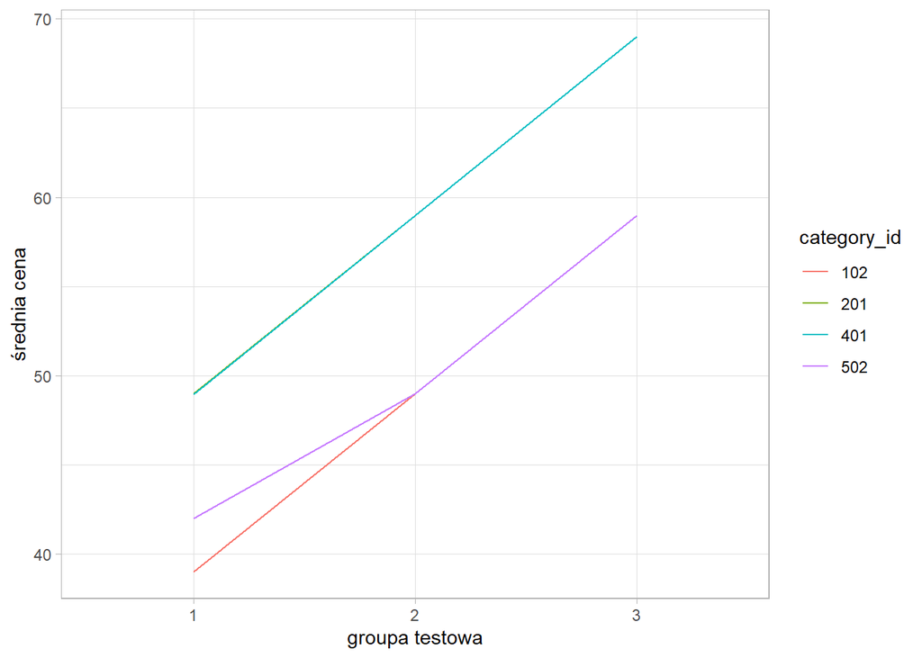

```r
mean_price %>%  ggplot(aes(as.numeric(group_pp), mean_price, col = category_id))+
  geom_line() +
  theme_light() +
  labs(y="średnia cena", x = "groupa testowa") +
  scale_x_discrete(limits=c("1","2","3"))
```

### Analiza danych

Mimo, że testujemy pakiet nr “75” należy zadać sobie pytanie, czy istnieją statystycznie istotne różnice pomiędzy grupami testowymi w kwestii wyboru pakietu.

```r
panderOptions('knitr.auto.asis', FALSE)

for (category in unique(data_all_packages$category_id)){
  print(category)
  data_all_packages %>% filter(category_id == category) %>%
    with(table(group_pp,price)) %>%
    addmargins() %>%
    pander()

}
```

[1] “102”

|  | 0 | 39 | 49 | 59 | 79 | 99 | 129 | Sum |
| --- | --- | --- | --- | --- | --- | --- | --- | --- |
| **1** | 368 | 624 | 0 | 0 | 513 | 0 | 61 | 1566 |
| **2** | 439 | 0 | 558 | 0 | 587 | 0 | 64 | 1648 |
| **3** | 390 | 0 | 0 | 349 | 579 | 1 | 70 | 1389 |
| **Sum** | 1197 | 624 | 558 | 349 | 1679 | 1 | 195 | 4603 |

[1] “201”

|  | 0 | 49 | 59 | 69 | 99 | 129 | 149 | Sum |
| --- | --- | --- | --- | --- | --- | --- | --- | --- |
| **1** | 101 | 172 | 0 | 0 | 256 | 0 | 73 | 602 |
| **2** | 123 | 0 | 169 | 0 | 250 | 0 | 68 | 610 |
| **3** | 88 | 0 | 0 | 121 | 255 | 1 | 62 | 527 |
| **Sum** | 312 | 172 | 169 | 121 | 761 | 1 | 203 | 1739 |

[1] “502”

|  | 0 | 42 | 49 | 59 | 79 | 99 | 129 | 149 | Sum |
| --- | --- | --- | --- | --- | --- | --- | --- | --- | --- |
| **1** | 42 | 87 | 0 | 0 | 103 | 1 | 25 | 0 | 258 |
| **2** | 43 | 0 | 71 | 0 | 87 | 0 | 34 | 1 | 236 |
| **3** | 45 | 0 | 0 | 54 | 96 | 0 | 22 | 0 | 217 |
| **Sum** | 130 | 87 | 71 | 54 | 286 | 1 | 81 | 1 | 711 |

[1] “401”

|  | 0 | 42 | 49 | 59 | 69 | 99 | 149 | Sum |
| --- | --- | --- | --- | --- | --- | --- | --- | --- |
| **1** | 143 | 1 | 233 | 0 | 0 | 204 | 55 | 636 |
| **2** | 155 | 0 | 0 | 182 | 0 | 246 | 31 | 614 |
| **3** | 149 | 0 | 0 | 0 | 149 | 196 | 28 | 522 |
| **Sum** | 447 | 1 | 233 | 182 | 149 | 646 | 114 | 1772 |

Można zaobserwować, że każda grupa testowa różniła się ceną jednego pakietu (“75”), podczas gdy pozostałe pakiety miały ustaloną wartość. Pojawiają się pondto pewne sepcyficzne ogłoszenia, które mają inną cenę, co może wynikać ze zmiany kategorii ogłoszenia, do którego zostało przypisane (np. użytkownik zapłacił za ogłoszenie 42 zł w jednej kategorii, które to następnie zostało przenisione do innej kategorii). W związku z powyższym możemy założyć, że róznice w wyborze pakietu wynikały z ceny tego konkretnego pakietu (lub różnic cenowych pomiędzy tym pakietem, a pozostałymi), a więc możemy odrzucić pozostałe pakiety z analizy kosztu. Zanim jednak to zrobimy warto spojrzeć, czy wzrost ceny pakietu “75” przekładał się na wzrost zakupionych innych pakietów:

```r
plotAdvertsiements <- function(category){
  data_all_packages %>%
    filter(category_id == category) %>%
    with(table(group_pp,price)) %>%
    addmargins() %>%
    as.data.frame.matrix() %<>%
    sapply('/', .[,'Sum']) %>%
    as.data.frame.matrix() %>%
    mutate(group = c(1:3,"all")) %>%
    select(-Sum) %>%
    gather(price,n,-group) %>%
    filter(n!=0 & group != "all") %>%
    ggplot(aes(as.numeric(price),n, col = group)) +
    geom_line(lwd = 1)+
    geom_point() +
    theme_light() +
    labs(x= "Cena", y = "Udział ogłoszeń")
}
```

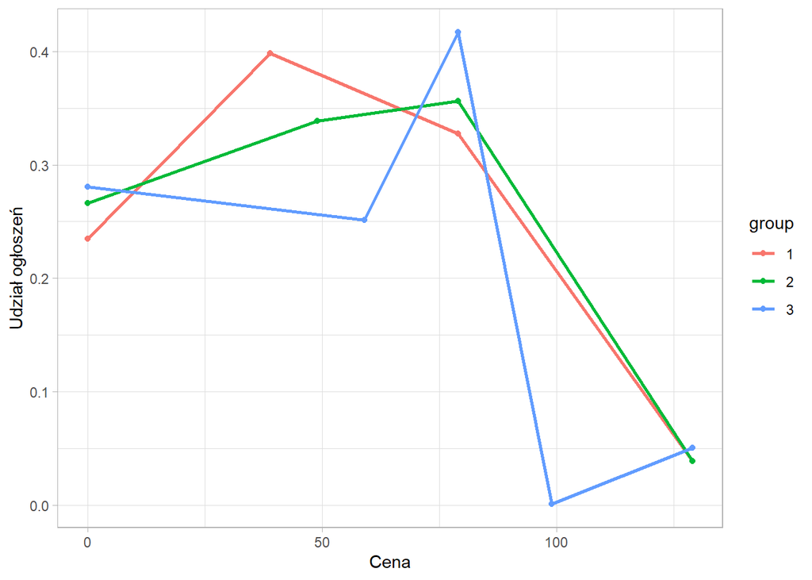

```r
plotAdvertsiements(102)
```

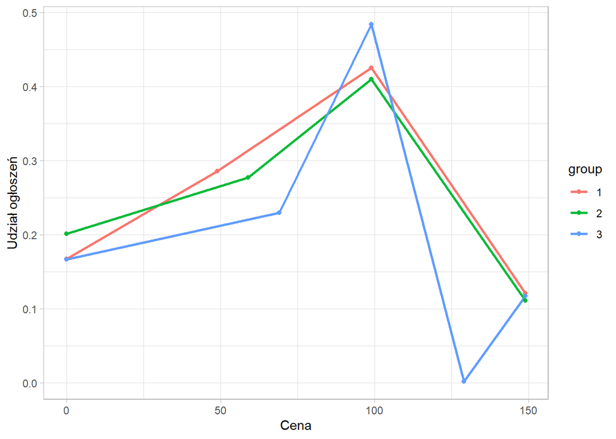

```r
plotAdvertsiements(201)
```

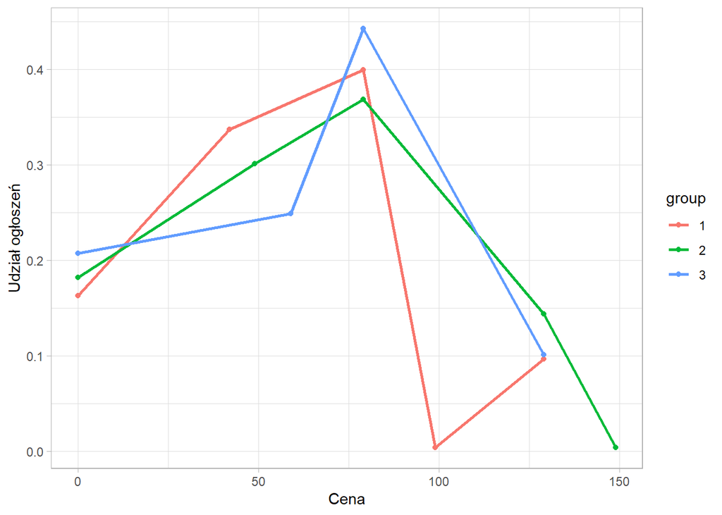

```r
plotAdvertsiements(502)
```

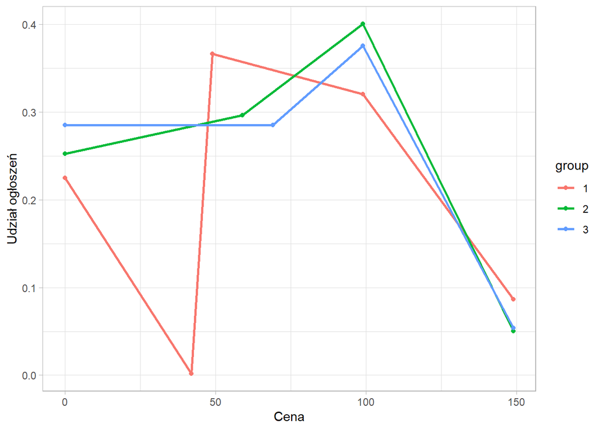

```r
plotAdvertsiements(401)
```

poza kategorią 401 można zaobserwować, że kiedy cena najtańszego pakietu (pakietu nr 75) wzrosła w grupie 3 do maksymalnej wartości większy udział osób zaczęła wykupywać droższy pakiet. W kategorii 401 taką sytuację można zaobserwować już od drugiej grupy testowej. Należy mieć to na uwadze, gdyż ogólny przychód z danej kategorii nie będzie uzależniony tylko od ceny poszczególnych pakietów, ale również od relacji pomiędzy nimi (różnicy cen i zawartości pakietów) - gdy cena jednego pakietu za bardzo zbliży się do ceny drugiego nagle niewiele droższy pakiet o lepszej zawartości staje się bardziej atrakcyjny.

Dalsza analiza oparta jest o ogłoszenia z pakietu nr “75” bez uwzględnienia pozostałych pakietów ponieważ ich ceny pozostały bez zmian.

Wybrane ceny pakietów wg grup testowych w poszczególnych kategoriach: (**przychod_jednost** - przychód całkowity podzielony przez wszystkie ogłoszenia opłacone i nieopłacone; **odpływ klientów** liczony jest jako udział ogłoszeń nieopłaconych - *unpaid* do we wszystkich ogłoszeniach w danej grupie testowej;)

```r
panderOptions('knitr.auto.asis', FALSE)

for(category in sort(unique(all_data$category_id))){
  print(category)
  data_price <- all_data %>%
    filter(category_id == category) %>%
    with(table(group_pp, price))

  data_price <- data_price %>%
    as.data.frame.matrix() %>%
    mutate(przychod_jednost = apply(.,1, FUN = calc_price),
           odplyw_klientow = apply(., 1, FUN = calc_decrease_client))
  assign(paste0("data_price_",category),data_price)

    data_price %>%
    pander()

}
```

[1] “102”

| 0 | 39 | 49 | 59 | przychod_jednost | odplyw_klientow |
| --- | --- | --- | --- | --- | --- |
| 358 | 624 | 0 | 0 | 24.78 | 0.36 |
| 426 | 0 | 558 | 0 | 27.79 | 0.43 |
| 374 | 0 | 0 | 349 | 28.48 | 0.52 |

[1] “201”

| 0 | 49 | 59 | 69 | przychod_jednost | odplyw_klientow |
| --- | --- | --- | --- | --- | --- |
| 95 | 172 | 0 | 0 | 31.57 | 0.36 |
| 118 | 0 | 169 | 0 | 34.74 | 0.41 |
| 86 | 0 | 0 | 121 | 40.33 | 0.42 |

[1] “401”

| 0 | 42 | 49 | 59 | 69 | przychod_jednost | odplyw_klientow |
| --- | --- | --- | --- | --- | --- | --- |
| 139 | 1 | 233 | 0 | 0 | 30.72 | 0.37 |
| 152 | 0 | 0 | 182 | 0 | 32.15 | 0.46 |
| 143 | 0 | 0 | 0 | 149 | 35.21 | 0.49 |

[1] “502”

| 0 | 42 | 49 | 59 | przychod_jednost | odplyw_klientow |
| --- | --- | --- | --- | --- | --- |
| 41 | 87 | 0 | 0 | 28.55 | 0.32 |
| 42 | 0 | 71 | 0 | 30.79 | 0.37 |
| 40 | 0 | 0 | 54 | 33.89 | 0.43 |

**ANALIZA CZASOWA OGŁOSZEŃ**

Czy działania użytkowników odbywały się w tym samym czasie? Całkowita liczba ogłoszeń tygodniowo w podziale na kategorie i grupy testowe:

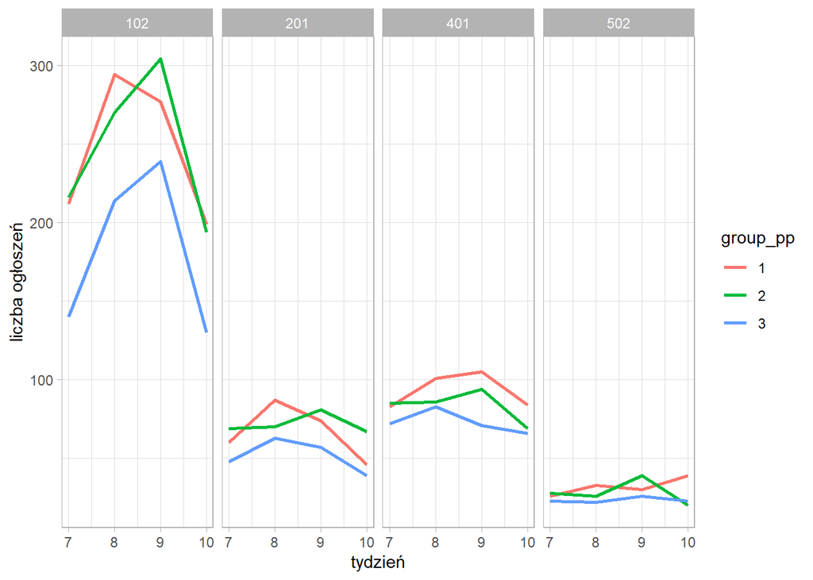

```r
all_data %>%
  group_by(week = week(created_at), category_id, group_pp) %>%
  count() %>%
  ggplot(aes(x= week, y = n, col = group_pp)) +
  geom_line(lwd = 1) +
  facet_grid(~category_id) +
  theme_light() +
  labs(y="liczba ogłoszeń", x = "tydzień")
```

najwięcej ogłoszeń pojawiło się w aktegorii “102”. Wyraźnie można również zaobserwować, że w grpie testowej nr 3 tygodniowo było mniej ogłoszeń niż w pozostałych grupach testowych. Należy jednak zauważyć, że częściowo może to wynikać z tego, że do trzeciej grupy wybrano również znacząco mniej użytkowników:

```r
liczba_uzytkownikow <- all_data %>%
  select(user_id,group_pp, category_id) %>%
  distinct() %>%
  group_by(group_pp, category_id) %>%
  summarise(liczba_uzytkownikow = n())

liczba_ogloszen <-all_data %>%
  select(ad_id, group_pp, category_id) %>%
  distinct() %>%
  group_by(group_pp, category_id) %>%
  summarise(liczba_ogloszen = n())

liczba_uzytkownikow %>%
  group_by(group_pp) %>%
  summarise(n = sum(liczba_uzytkownikow))
```

| group_pp | n |
| --- | --- |
| 1 | 1632 |
| 2 | 1578 |
| 3 | 1224 |

Również liczba ogłoszeń w wwyższej grupie jest niższa:

```r
liczba_ogloszen %>%
  group_by(group_pp) %>%
  summarise(n = sum(liczba_ogloszen))
```

| group_pp | n |
| --- | --- |
| 1 | 1750 |
| 2 | 1718 |
| 3 | 1316 |

W podziale na kategorie można zaobserwować również pewne zróżnicowanie:

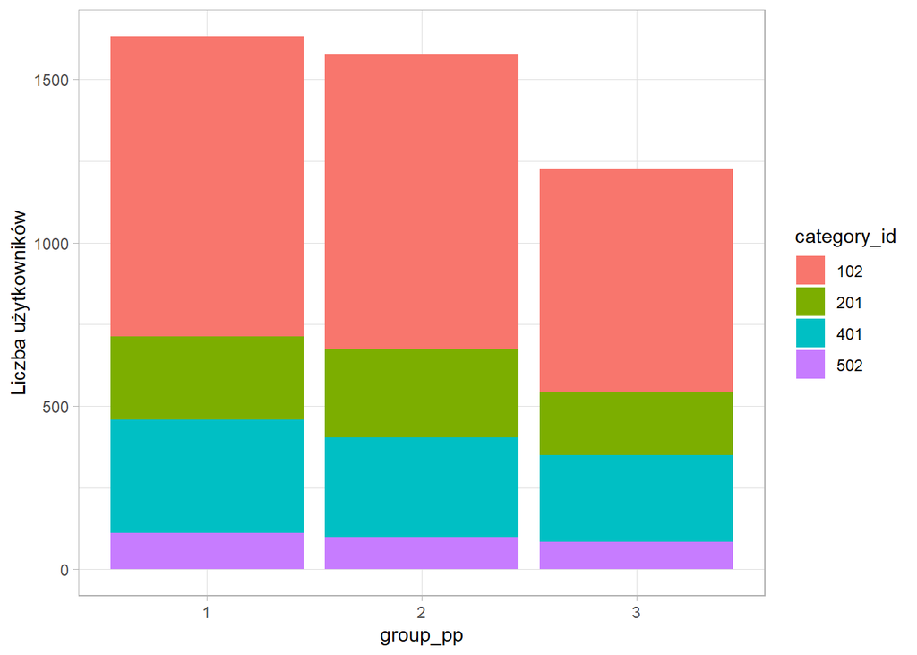

```r
liczba_uzytkownikow %>%
  ggplot(aes(group_pp, liczba_uzytkownikow, fill = category_id)) +
  geom_col()+
  theme_light() +
  labs(y= "Liczba użytkowników")
```

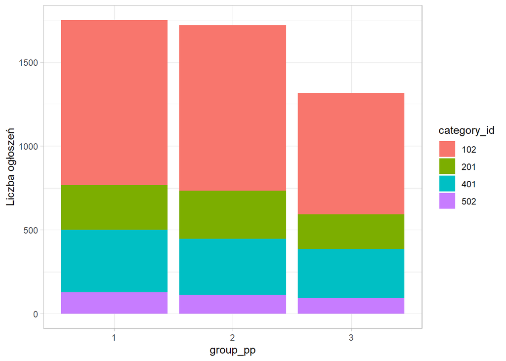

```r
liczba_ogloszen %>%
  ggplot(aes(group_pp, liczba_ogloszen, fill = category_id)) +
  geom_col()+
  theme_light() +
  labs(y= "Liczba ogłoszeń")
```

Udział *opłaconych* ogłoszeń tygodniowo w podziale na kategorie i grupy testowe we wszystkich ogłoszeniach w danej kategorii:

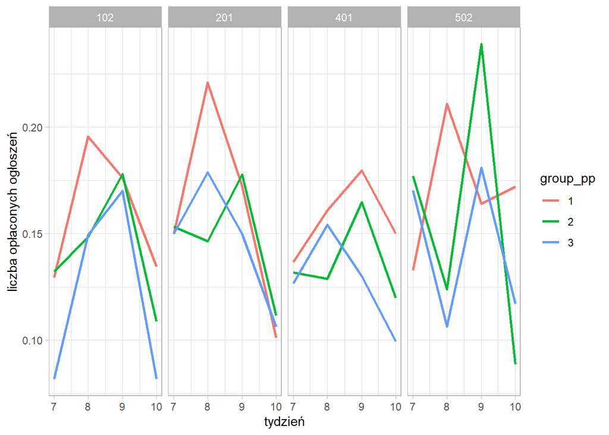

```r
all_data <- all_data %>%
  left_join(liczba_ogloszen, by = c("category_id", "group_pp"))

all_data %>%
  filter(status == 'paid') %>%
  group_by(week = week(created_at), category_id, group_pp) %>%
  summarise(n=n(),liczba_ogloszen = median(liczba_ogloszen)) %>%
  ggplot(aes(x= week, y = n/liczba_ogloszen, col = group_pp)) +
  geom_line(lwd = 1) +
  facet_grid(~category_id) +
  theme_light() +
  labs(y="liczba opłaconych ogłoszeń", x = "tydzień")
```

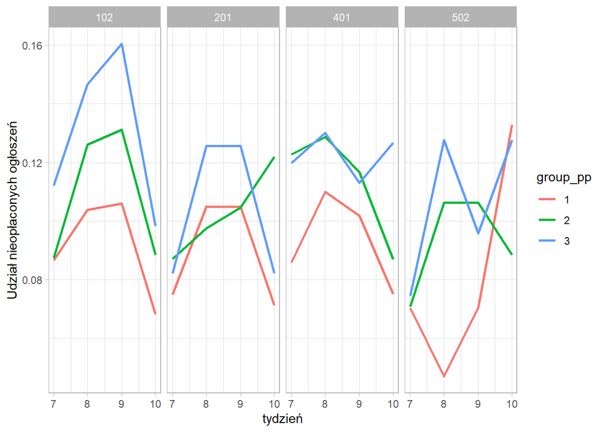

```r
all_data %>%
  filter(status == 'unpaid') %>%
  group_by(week = week(created_at), category_id, group_pp) %>%
 summarise(n=n(),liczba_ogloszen = median(liczba_ogloszen)) %>%
  ggplot(aes(x= week, y = n/liczba_ogloszen, col = group_pp)) +
  geom_line(lwd = 1) +
  facet_grid(~category_id) +
  theme_light() +
  labs(y="Udział nieopłaconych ogłoszeń", x = "tydzień")
```

Im wyższa cena pakietu, tym wyższy udział nieopłaconych ogłoszeń

Udział *opłaconych* ogłoszeń w całkowitej liczbie ogłoszeń tygodniowo w podziale na kategorie i grupy testowe:

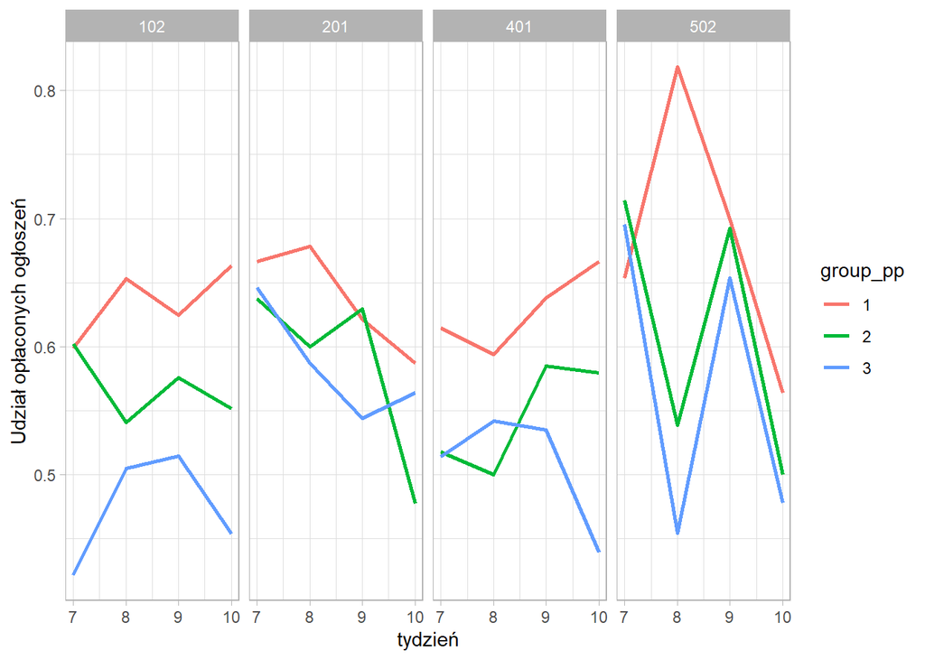

```r
all_data %>%
  group_by(week = week(created_at), category_id, group_pp, status) %>%
  count() %>%
  spread(status, n) %>%
  ggplot(aes(x= week, y = paid/(paid+unpaid), col = group_pp)) +
  geom_line(lwd = 1) +
  facet_grid(~category_id) +
  theme_light() +
  labs(y="Udział opłaconych ogłoszeń", x = "tydzień")
```

Przychód z *opłaconych* ogłoszeń tygodniowo:

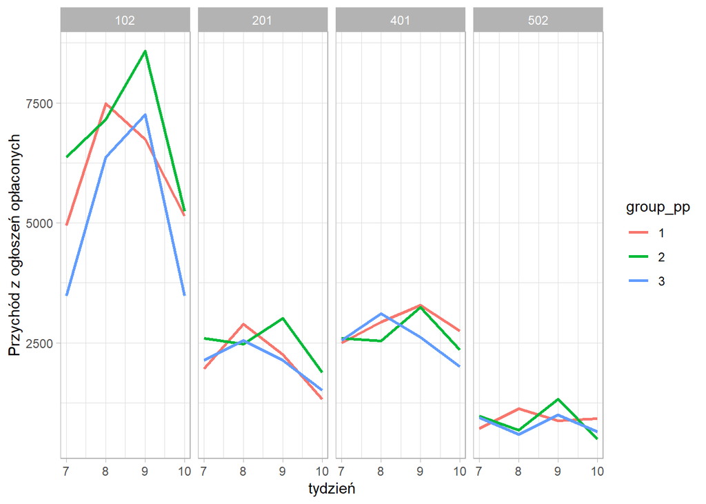

```r
all_data %>%
  filter(status == 'paid') %>%
  group_by(week = week(created_at), category_id, group_pp) %>%
  summarise(przychod = sum(price)) %>%
  ggplot(aes(x= week, y = przychod, col = group_pp)) +
  geom_line(lwd = 1) +
  facet_grid(~category_id) +
  theme_light() +
  labs(y="Przychód z ogłoszeń opłaconych", x = "tydzień")
```

Testy pakietu zostały przeprowadzone w tym samym czasie dla każdej grupy testowej, co umożliwia porównywanie wyników. Warto zadać sobie pytanie, skąd obserwowalne duże różnice w poszczególnych tygodniach widoczne szczególnie w kategorii “102”, dla której w 8 i 9 tygodniu roku przychód jak i liczba ogłoszeń oraz (co istotne) udział ogłoszeń nieopłaconych znacznie wzrosły.

### Wnioski

**Jaka powinna być cena za nasze usługi?**

Z analizy wynika, że im wyższa cena proponowana za pakiet, tym większy odpływ klientów. Jednocześnie im wyższa cena tym wyższy uzyskany przychód jednostkowy. Jednakże, jak wykazano wcześniej, liczba ogłoszeń wykupionych w danym pakiecie w danej kategorii zależy jednocześnie od cen pozostałych pakietów, a więc jeśli wprowadzimy zmianę w jednym z nich należy zakładać, że wprowadzenie w kolejnej fazie testów zmiany ceny w innym (w domyśle droższym) pakiecie może mieć również wpływ na sprzedaż pakeitu o cenie niższej.

Jeśli jednak opierać się tylko na wynikach uzyskanych w przeprowadzonym eksperymentu teście można pokusić się o analizę, czy przychód jednostkowy rozumiany jako średni przychód z ogłoszenia w danej kategorii różni się istotnie statystycznie pomiędzy grupami testowymi. Zadanie to jest o tyle trudne, że nie mówimy tu o rozkładzie normalnym wartości (cen), jak również populacje są z gruntu różne ponieważ ceny podawane grupom testowym były różne. W związku z powyższym proponwany jest test Kruskalla-Wallisa w celu określenia różnic w średniej cenie pomiędzy grupami.

```r
kruskal.test(data_all_packages$price,
             data_all_packages$group_pp) %>%
  pander()
```

Kruskal-Wallis rank sum test: `data_all_packages$price` and `data_all_packages$group_pp`

| Test statistic | df | P value |
| --- | --- | --- |
| 81.8 | 2 | 1.731e-18 * * * |

Jak wynika z przeprowadzonego testu średni przychód z ogłoszenia różni sie istotnie pomiędzy grupami. Przychód z ogłoszenia jest najwyższy w trzeciej grupie testowej, a więc dla najwyższej ceny w danej kategorii.

W poszczególnych kategoriach proponowana na podstawie przeprowadzonych testów cena wynosi:

102: **59**

201: **69**

401: **69**

502: **59**

**Czy wprowadzenie nowych cenników nie spowoduje odpływu klientów, jeżeli tak, to jakich strat możemy się spodziewać?**

Wzrost ceny wiąże się z większym odsetkiem osób rezygnujących z pulikacji ogłoszenia. Warto pokusić się o sprawdzenie, czy różnice w odsetku osób rezygnujących z ogłoszenia jest również istotny statystycznie.

```r
data_all_packages %>%
  mutate(status2 = factor(status, labels = c(0,1),levels = c('unpaid','paid'))) %>%
  with(.,kruskal.test(status2, group_pp)) %>%
  pander()
```

Kruskal-Wallis rank sum test: `status2` and `group_pp`

| Test statistic | df | P value |
| --- | --- | --- |
| 14.07 | 2 | 0.0008797 * * * |

Również w przypadku różnic w udziale osób rezygnujących z ogłoszenia można stwierdzić statystyczną istotność.

Wysokość odpływu klientów w zależności od kategorii oraz grupy testowej (ceny pakietu) zaprezentowano już w zakładce *Analiza Danych*, ale dla przypomnienia:

```r
for(category in sort(unique(all_data$category_id))){
  print(category)
  data_price <- all_data %>%
    filter(category_id == category) %>%
    with(table(group_pp, price))

  data_price <- data_price %>%
    as.data.frame.matrix() %>%
    mutate(odplyw_klientow = apply(., 1, FUN = calc_decrease_client))
  assign(paste0("data_price_",category),data_price)

    data_price %>%
    pander()

}
```

[1] “102”

| 0 | 39 | 49 | 59 | odplyw_klientow |
| --- | --- | --- | --- | --- |
| 358 | 624 | 0 | 0 | 0.36 |
| 426 | 0 | 558 | 0 | 0.43 |
| 374 | 0 | 0 | 349 | 0.52 |

[1] “201”

| 0 | 49 | 59 | 69 | odplyw_klientow |
| --- | --- | --- | --- | --- |
| 95 | 172 | 0 | 0 | 0.36 |
| 118 | 0 | 169 | 0 | 0.41 |
| 86 | 0 | 0 | 121 | 0.42 |

[1] “401”

| 0 | 42 | 49 | 59 | 69 | odplyw_klientow |
| --- | --- | --- | --- | --- | --- |
| 139 | 1 | 233 | 0 | 0 | 0.37 |
| 152 | 0 | 0 | 182 | 0 | 0.46 |
| 143 | 0 | 0 | 0 | 149 | 0.49 |

[1] “502”

| 0 | 42 | 49 | 59 | odplyw_klientow |
| --- | --- | --- | --- | --- |
| 41 | 87 | 0 | 0 | 0.32 |
| 42 | 0 | 71 | 0 | 0.37 |
| 40 | 0 | 0 | 54 | 0.43 |

Procentowy udział osób rezygnujących z publikacji ogłoszeń mieści się w zakresie od ok 30 do 50% w zależności od kategorii i grupy testowej.

Wzrost ceny rekompensuje odpływ klientów, jednak, jak wcześniej pisałem, należy sobie zadać pytanie co jest ważniejsze: przychód w danym momencie, czy stabilny udział w rynku.

**Czy wyniki są istotne statystycznie, czy jednak serwis powinien prowadzić dalej testy?**

Choć wyniki są istotne statystycznie należy kontynuować testy jednak zmieniając ceny pozostałych pakietów i poszukując optimum ceny w stosunku do sprzedaży. Należy dobrze zastanowić się nad metrykami, które chce się optymalizować. Maksymalny przychód z ogłoszeń może oznaczać istotnie mniejszy udział na rynku ze względu na liczbę klientów, która może przenieść się do konkurencji i w dłuższej perspektywie czasowej może spowodować dodatnie sprzężenie zwrotne w postaci narastającego odpływu klientów. Pojawia się w związku z tym szereg pytań, które zostały zaprezentowane poniżej:

1. Jaki jest maksymalny odpływ klientów dopuszczalny przez firmę w danej kategorii (lub inaczej mówiąc: jaki udział rynku możemy oddać konkurencji)?
2. Co wpływa na wybór pakietu? Czy istnieje relacja pomiędzy wiekiem, płcią i wykształceniem, a decyzją o kupnie pakietu w danej kategorii? Czy miejsce zamieszkania może stanowić proxy zamożności klienta i jednocześnie wpływać na wartość pakietu jaką jest gotów zapłacić?
3. Czy da się opracować model szacujący maksymalną wysokość ceny pakietu dla poszczególnych klientów? nie wykluczone, że zależność pomiędzy przychodem a ceną posiada kształt funkcji zbliżonej do normalnej krzywej Gaussa, gdzie punkt maksymalnego przychodu jest jednocześnie punktem, w którym wysokość ceny sprawia, że więcej osób rezygnuje z ogłoszenia niż zwraca się koszt tych ogłoszeń w jego cenie.
4. Jeżeli takie cechy jak płeć, czy wiek wpływają na gotowość zakupu droższego pakietu, czy prezentowanie różnych cen na podstawie tych cech jest legalne i moralnie właściwe, czy stanowi swego rodzaju dyskryminację?

### Dalszy rozwój rozwiązania

1. Przeprowadzenie kolejnych testów ze zmianami cen w pozostałych pakietach.
2. Proponowane rozwiązanie można **usprawnić zamykając je w kontenerze (dockeryzacja) i umieszczając na serwerze udostępniając jednocześnie komunikację z utworzonym narzędziem poprzez REST**.
3. Zbudowanie **aplikacji Shiny**, w której można będzie zdefiniować maksymalny dopuszczalny poziom odpływu klientów, by zwizualizować szacowany zysk przy danej cenie.
4. Zbudowanie zespołu analitycznego, do zaplanowania długofalowego, wielofazowego eksperymentu oraz możliwości statystycznej analizy danych.